# docana-game-zeyuan

```python
pip install pandas
```

```python
import pandas as pd
from datasets import load_dataset
```

```python
from datasets import load_dataset

ds = load_dataset("webis/tldr-17", split="train", trust_remote_code=True)
```

```python
import pandas as pd

df = ds.to_pandas()
df = df[['subreddit', 'body']].dropna()
```

```python
df
```

```python
# Define target game subreddits
game_subreddits = ['leagueoflegends', 'pokemon', 'zelda', 'Overwatch', 'smashbros', 'hearthstone']

# Filter the DataFrame
df_games = df[df['subreddit'].isin(game_subreddits)].copy()

print(df_games['subreddit'].value_counts())
```

Preprocessing is an important step in our analysis. We remove elements that are not helpful for our task, such as links, stop words, and anything that is not a letter or space. In addition to stop words, we noticed that some phrases still appeared as important despite the stop word removal — for example, phrases like “quick play”, “ranked games”, or “playing overwatch”. To address this, we also removed certain domain-specific words like “play”, “playing”, “game”, etc., so that phrases containing these words would not dominate the results. Furthermore, we removed any text that appears after a TL;DR (in any form) because it could bias the phrase extraction towards words that are common in summaries. Summaries often repeat key points in a condensed way rather than reflecting the natural flow of the document.

```python
import re
import nltk
from nltk.corpus import stopwords

nltk.download('stopwords')
stop_words = set(stopwords.words('english'))

common_words = {"game", "games", "gaming", "player", "play", "playing"}

def remove_tldr(text):
    pattern = re.compile(r'(tl;dr|tldr|tl dr|tl:dr)', re.IGNORECASE)
    match = pattern.search(text)
    if match:
        return text[:match.start()].strip()
    return text

def preprocess(text):
    text = remove_tldr(text)
    text = text.lower()
    text = re.sub(r"http\S+|www\S+|https\S+", '', text) #removes links if any
    text = re.sub(r'[^a-z\s]', ' ', text) #replaces anything that is not a letter or space with a space
    text = re.sub(r'\s+', ' ', text).strip() #replace multiple whitespace characters with a single space
    tokens = text.split()
    tokens = [word for word in tokens if word not in stop_words and word not in common_words]
    return " ".join(tokens)

# Apply to your filtered gaming dataset
df_games['cleaned_body'] = df_games['body'].apply(preprocess)
```

```python
from wordcloud import WordCloud
import matplotlib.pyplot as plt

# Join all cleaned text
all_text = " ".join(df_games['cleaned_body'])

# Generate word cloud
wordcloud = WordCloud(width=800, height=400, background_color='white').generate(all_text)

wordcloud.to_image()
```

[output not shown]

```python
df_games[['subreddit', 'body', 'cleaned_body']].head()
```

```python
# Group posts by subreddit and concatenate all texts
grouped = df_games.groupby('subreddit')['cleaned_body'].apply(lambda texts: ' '.join(texts)).reset_index()
```

```python
from sklearn.feature_extraction.text import TfidfVectorizer
```

We want to identify which bigrams are most characteristic of each subreddit. To do this, we compute the importance of specific bigrams (2-word phrases) or trigrams (3-word phrases) for each subreddit using TF-IDF.

```python
# Create the vectorizer
vectorizer = TfidfVectorizer(ngram_range=(2,3), max_df=0.6, use_idf=True)  #max_df: ignores bigrams that appear in more than 60% of documents

# Fit and transform
tfidf_matrix = vectorizer.fit_transform(grouped['cleaned_body'])

# Convert to DataFrame
tfidf_df = pd.DataFrame(tfidf_matrix.toarray(), index=grouped['subreddit'], columns=vectorizer.get_feature_names_out())
```

```python
tfidf_df
```

The higher the score, the more unique and important that bigram is for that subreddit.

```python
# Get top N unique terms
top_n = 20
for subreddit in tfidf_df.index:
    print(f"\n🔹 Top {top_n} terms for r/{subreddit}:")
    top_terms = tfidf_df.loc[subreddit].sort_values(ascending=False).head(top_n)
    print(top_terms)
```

[output not shown]

```python
# !Run this if you want to see the top 100 phrases for each subreddit
top_phrases = []

for subreddit, row in tfidf_df.iterrows():
    top = row.sort_values(ascending=False).head(100)
    for phrase, score in top.items():
        top_phrases.append({'subreddit': subreddit, 'phrase': phrase, 'tfidf_score': score})

top_100_df = pd.DataFrame(top_phrases)
top_100_df.to_csv('top_100_phrases_per_subreddit.csv', index=False)
```

until here correct

```python
import nltk
nltk.download('punkt')
from nltk.tokenize import word_tokenize
```

# -1.Option-

Use Gensim’s Phrases model

-It automatically detects collocations based on their co-occurrence frequencies and statistical association

-Learns phrases that appear together significantly more than chance

-Can find multi-word phrases beyond what TF-IDF would capture

```python
#FOR WORD2VEC
#Tokenize the cleaned body
tokenized_docs = df_games['cleaned_body'].apply(str.split).tolist()
print(tokenized_docs[0][:20])
```

We used Gensim’s Phrases model to multi-word expressions like "wind waker" and treat them as single tokens like wind_waker.

```python
from gensim.models import Phrases
from gensim.models.phrases import Phraser
#Train a Phrases model on tokenized_docs

# Detect frequent bigrams
phrases = Phrases(tokenized_docs, min_count=5, threshold=10)
bigram_model = Phraser(phrases) #bigrams are joined (wind_waker)

# Apply the model to tokenized text
corpus_phrased = [bigram_model[doc] for doc in tokenized_docs]

print(corpus_phrased[0][:50])  # it doesn’t have phrases that meet the criteria
print(corpus_phrased[1][:50])  # see the detected bigrams merged with underscores
```

## Training Word2Vec

The Word2Vec model was trained on this phrased corpus (corpus_phrased), where common multi-word expressions were merged with underscores.

We used the skip-gram architecture to learn embeddings that predict surrounding context words.

The model had an embedding size of 100 dimensions, a window size of 5, and ignored tokens that appeared fewer than 5 times.

```python
from gensim.models import Word2Vec
from gensim.models.callbacks import CallbackAny2Vec
from tqdm import tqdm

class EpochLogger(CallbackAny2Vec):
    def __init__(self, epochs):
        self.epochs = epochs
        self.pbar = tqdm(total=epochs, desc='Training Epochs')

    def on_epoch_end(self, model):
        self.pbar.update(1)

    def on_train_end(self, model):
        self.pbar.close()

# Then train the model with the callback

epoch_logger = EpochLogger(epochs=5)

w2v_model = Word2Vec(
    sentences=corpus_phrased,
    vector_size=100,   # Embedding dimensions
    window=5,    # Context window
    min_count=5,  # Ignore rare words
    sg=1,    # Use skip-gram (1) or CBOW (0)
    workers=4,
    epochs=5, # increase this for better training (epochs = 10)
    callbacks=[epoch_logger]
)
```

For each subreddit, we identified the top 20 most distinctive phrases (those with the highest TF-IDF scores). These phrases were collected into a set, merged with underscores, and converted to the same format (e.g., legend of zelda - legend_of_zelda), since the Word2Vec model was trained on text where frequent phrases were joined with underscores.

```python
# Initialize an empty set to avoid duplicates
unique_phrases = set()

# Collect top 20 TF-IDF phrases for each subreddit
top_n = 20
for subreddit in tfidf_df.index:
    top_terms = tfidf_df.loc[subreddit].sort_values(ascending=False).head(top_n)
    unique_phrases.update(top_terms.index)

# Convert set to list
unique_phrases = list(unique_phrases)

# Convert phrases to gensim format (with underscores)
unique_phrases = [phrase.replace(" ", "_") for phrase in unique_phrases]
```

```python
#See the most 20 similar words/phrases
for phrase in unique_phrases:
    try:
        similar = w2v_model.wv.most_similar(phrase, topn=20)
        print(f"\n Phrase: {phrase}")
        for word, score in similar:
            print(f"    {word} (score: {score:.3f})")
    except KeyError:
        print(f"\nPhrase '{phrase}' not in Word2Vec vocabulary.")
```

[output not shown]

We extracted the 20 nearest neighbors determined by cosine similarity in vector space to chosen phrase. The results reflect how phrases are used in context across communities, offering insight into their meanings and associations in gaming discourse.

## PCA

Since these embeddings are high-dimensional, we applied Principal Component Analysis (PCA) to reduce them to 2 dimensions (X_reduced) for visualization.

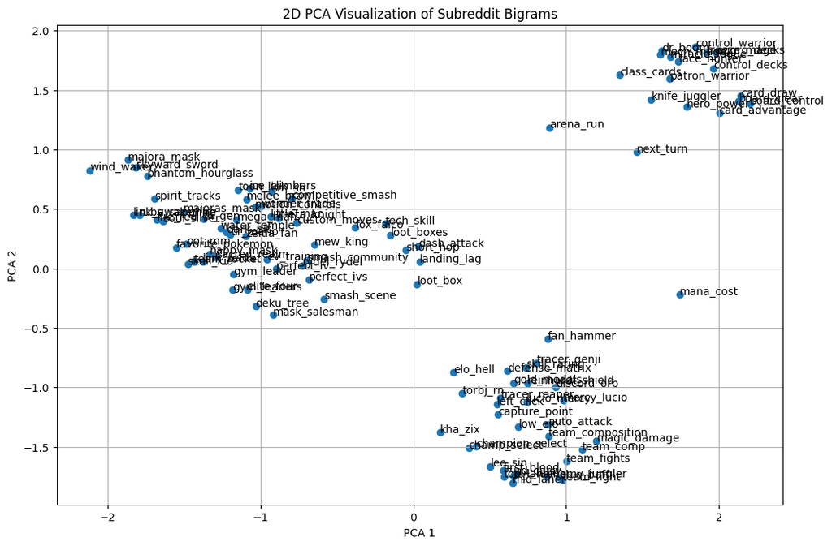

```python
import numpy as np
from sklearn.decomposition import PCA
import matplotlib.pyplot as plt

# Filter to only those in the vocab
valid_phrases = [p for p in unique_phrases if p in w2v_model.wv]

# Get their vectors
X = np.array([w2v_model.wv[p] for p in valid_phrases])

# Reduce to 2D
pca = PCA(n_components=2)
X_reduced = pca.fit_transform(X)

# Plot
plt.figure(figsize=(12, 8))
plt.scatter(X_reduced[:, 0], X_reduced[:, 1])

for i, phrase in enumerate(valid_phrases):
    plt.annotate(phrase, (X_reduced[i, 0], X_reduced[i, 1]))

plt.title("2D PCA Visualization of Subreddit Bigrams")
plt.xlabel("PCA 1")
plt.ylabel("PCA 2")
plt.grid(True)
plt.show()
```

Phrases that appear close together likely have similar meanings or occur in similar contexts in subreddit data.

Phrases that are far apart are less related in terms of usage/context.

Since TfidfVectorizer was set to ngram_range=(2, 3), it only considered bigrams and trigrams (no unigrams). As a result, all the top terms I extracted were bigrams or trigrams in PCA.

```python
import plotly.express as px
import pandas as pd
import plotly.io as pio

# Set Plotly renderer
pio.renderers.default = 'notebook'

# Check data availability
#print(X_reduced.shape)
#print(valid_phrases)

# Create a DataFrame for Plotly
pca_df = pd.DataFrame({
    'x': X_reduced[:, 0],
    'y': X_reduced[:, 1],
    'phrase': valid_phrases
})

# Create interactive scatter plot
fig = px.scatter(
    pca_df,
    x='x',
    y='y',
    text='phrase', #if this commented out, no text will show unless mouseover
    #hover_name='phrase',  # Show phrase on hover
    hover_data=['phrase'],  # Shows phrase on hover
    title="Interactive 2D PCA Visualization of Subreddit Bigrams"
)

# Adjust text position and size
fig.update_traces(
    textposition='top center',
    textfont_size=10,
    marker=dict(size=8)
)

# Add axis labels
fig.update_layout(
    xaxis_title="PCA 1",
    yaxis_title="PCA 2",
    hovermode='closest'
)

# Show the figure
fig.show(renderer='iframe')
```

[interactive chart not shown]

## K-Means Clustering

KMeans groups phrases with similar vector representations.

-The model tries to group together bigrams/trigrams that appeared in similar contexts across the data. For example, phrases about a particular game or character might cluster together because their usage patterns are similar.

-Each cluster may represent a different topic (e.g., one cluster's tokens could be related to Overwatch, another to Pokémon, etc.).

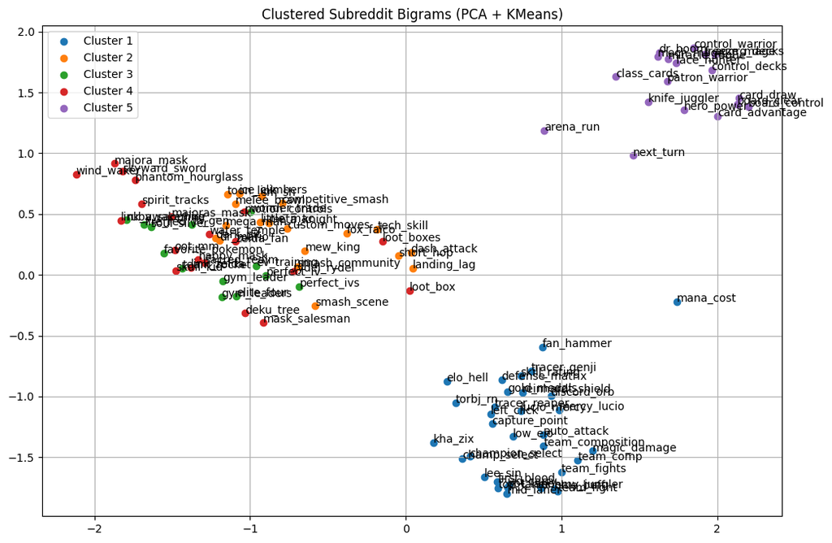

```python
from sklearn.cluster import KMeans

n_clusters = 5  # adjust this
kmeans = KMeans(n_clusters=n_clusters, random_state=42)
labels = kmeans.fit_predict(X)

# Plot with cluster colors
plt.figure(figsize=(12, 8))
for i in range(n_clusters):
    cluster_points = X_reduced[labels == i]
    plt.scatter(cluster_points[:, 0], cluster_points[:, 1], label=f"Cluster {i+1}")

# Add labels
for i, phrase in enumerate(valid_phrases):
    plt.annotate(phrase, (X_reduced[i, 0], X_reduced[i, 1]))

plt.title("Clustered Subreddit Bigrams (PCA + KMeans)")
plt.legend()
plt.grid(True)
plt.show()
```

```python
print(pca_df.columns)
```

### PCA and Clustering with Similar Word2vec embeddings

If we want to see also their distribution in vector space with their similar meanings, we include them as below.

```python
# TF-IDF phrases
all_terms = set(unique_phrases)

# For each, add its top similar terms
for phrase in unique_phrases:
    if phrase in w2v_model.wv:
        similar_terms = w2v_model.wv.most_similar(phrase, topn=10)
        for word, _ in similar_terms:
            all_terms.add(word)

# Convert to list
all_terms = list(all_terms)

# Filter to those in vocab
valid_terms = [t for t in all_terms if t in w2v_model.wv]

# Get vectors
X = np.array([w2v_model.wv[t] for t in valid_terms])

# PCA
pca = PCA(n_components=2)
X_reduced = pca.fit_transform(X)

# Plot
plt.figure(figsize=(12, 8))
plt.scatter(X_reduced[:, 0], X_reduced[:, 1])

for i, term in enumerate(valid_terms):
    plt.annotate(term, (X_reduced[i, 0], X_reduced[i, 1]), fontsize=9)

plt.title("PCA: TF-IDF Phrases + Their Similar Terms")
plt.grid(True)
plt.show()
```

[output not shown]

```python
n_clusters = 5  # adjust this
kmeans = KMeans(n_clusters=n_clusters, random_state=42)
labels = kmeans.fit_predict(X)

# Plot
plt.figure(figsize=(12, 8))
colors = plt.cm.get_cmap("tab10", n_clusters)

for i in range(n_clusters):
    cluster_points = X_reduced[labels == i]
    plt.scatter(cluster_points[:, 0], cluster_points[:, 1], label=f"Cluster {i+1}")

# Annotate points
for i, term in enumerate(valid_terms):
    plt.annotate(term, (X_reduced[i, 0], X_reduced[i, 1]), fontsize=9)

plt.title("K-Means Clustering of Phrases + Similar Terms (PCA Reduced)")
plt.legend()
plt.grid(True)
plt.show()
```

[output not shown]

```python
# Save the whole model
w2v_model.save("subreddit_bigrams_word2vec.model")

# Optionally: save just the vectors
w2v_model.wv.save_word2vec_format("subreddit_bigrams_vectors.txt")
```

```python
# Load the full model
#from gensim.models import Word2Vec
#model = Word2Vec.load("subreddit_bigrams_word2vec.model")

# Load vectors only
#from gensim.models import KeyedVectors
#vectors = KeyedVectors.load_word2vec_format("subreddit_bigrams_vectors.txt")
```

Should we remove more words like "team" etc.?